# ECON 413 Data Structures

Erol Taymaz  
Department of Economics  
Middle East Technical University

## Topics

- Data structures in R
- Data frames and indexing
- data.table package

## R script

- Open a new file (R Script)
- Save the file

  file name: **004_studentID.R**
- Load the libraries
  - data.table
  - ggplot2

```r
library(ggplot2)
library(data.table)
```

## Refresh our memory

- Key operators
- <- is the assignment operator (creates an object)
- = parameter assignment for functions
- == test equality (returns a logical variable)

```r
a <- 5
a
```

```
## [1] 5
```

```r
# The following also works
b = 8
b
```

```
## [1] 8
```

```r
# Duplicate the object
d <- b
d
```

```
## [1] 8
```

```r
# If you use the same name, it will be replaced WITHOUT AND WARNING
a <- 10
a
```

```
## [1] 10
```

- List all objects

```r
ls()
```

```
## [1] "a" "b" "d"
```

- List all objects with their description

```r
ls.str()
```

```
## a :  num 10
## b :  num 8
## d :  num 8
```

- Remove objects

```r
rm(a)
ls()
```

```
## [1] "b" "d"
```

- Remove all objects

```r
rm(list=ls())
ls()
```

```
## character(0)
```

- # means comment. Anything after the # symbol is ignored by R

```r
# 2 + 3
```

## Data modes

- Numeric
  - Integer
  - Double
- Character
- Logical
- Factor
- Date

```r
a <- 5
b <- "a"
c <- TRUE
d <- T
e <- "1"
# e + 1

class(e)
```

```
## [1] "character"
```

```r
is.numeric(e)
```

```
## [1] FALSE
```

```r
f <- as.numeric(e)
class(f)
```

```
## [1] "numeric"
```

```r
f + 1
```

```
## [1] 2
```

```r
rm(list=ls())
```

## Data types

- **Vectors**: A single column of data (even a column of length 1)
- **Matrices**: Two-dimensiona data (all rows and columns of all the same type)
- **Arrays**: Multi-dimensional data (all rows and columns of all the same type)
- **Dataframes**: Similar to matrics, but the columns can have different data types
  - Dataframes are the most common data structure in R
- **Datatables**: Similar to dataframes but uses a different syntax
- **Lists**: are arbitrary combinations of disparate object types in R

## Creating vectors

- : the sequence operator
- c() function
- rep() function
- seq() function
- sample() function
- rnorm() function

```r
# : creates an index
aa <- 1:3
aa
```

```
## [1] 1 2 3
```

```r
aa <- 100:103
aa
```

```
## [1] 100 101 102 103
```

```r
aa <- -3:3
aa
```

```
## [1] -3 -2 -1  0  1  2  3
```

```r
# c() combines values into a vector or a list
bb <- c(-1, 0, 1)
bb
```

```
## [1] -1  0  1
```

```r
cc <- c(-1:1)
cc
```

```
## [1] -1  0  1
```

```r
dd <- c(bb, cc)
dd
```

```
## [1] -1  0  1 -1  0  1
```

```r
bb <- c(1, 2, "a", "b", 5)
bb
```

```
## [1] "1" "2" "a" "b" "5"
```

```r
is.numeric(bb)
```

```
## [1] FALSE
```

```r
is.character(bb)
```

```
## [1] TRUE
```

```r
# Why?

bb <- c(1, 2, "a", "b", TRUE)
bb
```

```
## [1] "1"    "2"    "a"    "b"    "TRUE"
```

```r
bb <- c(1, 0, TRUE)
bb
```

```
## [1] 1 0 1
```

- rep() function

```r
?rep

rep(1:3, each = 2)
```

```
## [1] 1 1 2 2 3 3
```

```r
rep(1:3, times = 2)
```

```
## [1] 1 2 3 1 2 3
```

```r
rep(1:3, len = 5)
```

```
## [1] 1 2 3 1 2
```

```r
rep(1:3, each = 2, times = 3)
```

```
##  [1] 1 1 2 2 3 3 1 1 2 2 3 3 1 1 2 2 3 3
```

```r
rep(1:3, each = 2, len = 7)
```

```
## [1] 1 1 2 2 3 3 1
```

- seq() function

```r
?seq

seq(-1, 4)
```

```
## [1] -1  0  1  2  3  4
```

```r
seq(-1, 4, by = 2)
```

```
## [1] -1  1  3
```

```r
seq(-1, 4, length.out = 3)
```

```
## [1] -1.0  1.5  4.0
```

```r
# seq(-1, 4, by = 2, length.out = 3)
```

- rnorm() function ?rnorm

- Elements of a vector

```
aa <- c(10:1)
aa

# 3rd element of aa
aa[3]

# 3rd and 6th elements
aa[c(3, 6)]

# Get even numbers
aa[seq(1, 10, by = 2)]

rm(list=ls())
```

## Vector operations

```r
# Simple operations
aa <- c(1:10)
bb <- sample(aa, 10)
cc <- 5

dd <- aa * bb
ee <- aa > bb
ff <- aa > cc

max(aa)
```

```
## [1] 10
```

```r
max(aa, bb)
```

```
## [1] 10
```

```r
pmax(aa, bb)
```

```
##  [1]  8  2  9  5  6  6  7 10  9 10
```

```r
# aa * ee

# Changing elements
aa[5] <- 50
aa
```

```
##  [1]  1  2  3  4 50  6  7  8  9 10
```

```r
aa[1:3] <- 10 * aa[1:3]
aa
```

```
##  [1] 10 20 30  4 50  6  7  8  9 10
```

```r
aa[15] <- 15
aa
```

```
##  [1] 10 20 30  4 50  6  7  8  9 10 NA NA NA NA 15
```

```r
# Lag variables
aa <- c(1:10)
lagaa <- c(NA, aa[1:length(aa)-1])

# Growth rates
graa <- 100*((aa/lagaa) - 1)
graa
```

```
##  [1]        NA 100.00000  50.00000  33.33333  25.00000  20.00000  16.66667
##  [8]  14.28571  12.50000  11.11111
```

```r
round(graa, 1)
```

```
##  [1]    NA 100.0  50.0  33.3  25.0  20.0  16.7  14.3  12.5  11.1
```

```r
# Why vectors?

# Time
aa <- sample(100, 1000000, replace = TRUE)
bb <- sample(100, 1000000, replace = TRUE)
sumAB <- 0

system.time(for (i in c(1:length(aa))) {
  sumAB <- sumAB + (aa[i] < bb[i])
  })
```

```
##    user  system elapsed
##   0.226   0.008   0.234
```

```r
sumAB
```

```
## [1] 495116
```

```r
system.time(sumBA <- sum(aa < bb))
```

```
##    user  system elapsed
##   0.004   0.000   0.005
```

```r
sumBA
```

```
## [1] 495116
```

## Factors

- Factors are categorical variables
  - Unordered
  - Ordered

```r
aa <- c("small", "large", "medium")
aa
```

```
## [1] "small"  "large"  "medium"
```

```r
bb <- sample(3, 10, replace = TRUE)
bb
```

```
##  [1] 1 2 3 3 1 2 1 1 3 3
```

```r
aa <- aa[bb]
aa
```

```
##  [1] "small"  "large"  "medium" "medium" "small"  "large"  "small"
##  [8] "small"  "medium" "medium"
```

```r
class(aa)
```

```
## [1] "character"
```

```r
aaf <- factor(aa)
aaf
```

```
##  [1] small  large  medium medium small  large  small  small  medium medium
## Levels: large medium small
```

```r
as.numeric(aaf)
```

```
##  [1] 3 1 2 2 3 1 3 3 2 2
```

```r
as.numeric(aa)
```

```
##  [1] NA NA NA NA NA NA NA NA NA NA
```

```r
aaof <- ordered(aaf, levels=c("small", "medium", "large"))
aaof
```

```
##  [1] small  large  medium medium small  large  small  small  medium medium
## Levels: small < medium < large
```

```r
as.numeric(aaf)
```

```
##  [1] 3 1 2 2 3 1 3 3 2 2
```

```r
as.numeric(aaof)
```

```
##  [1] 1 3 2 2 1 3 1 1 2 2
```

```r
# Converting characters to numeric values
aa <- factor(c("3", "11", "2", "23", "313", "2"))
aa
```

```
## [1] 3   11  2   23  313 2
## Levels: 11 2 23 3 313
```

```r
aan <- as.numeric(aa)
aan
```

```
## [1] 4 1 2 3 5 2
```

```r
aan <- as.numeric(as.character(aa))
aan
```

```
## [1]   3  11   2  23 313   2
```

```r
rm(list=ls())
```

## Data frames

- nxm table
  - columns: variables (same data type)
  - rows: observations
- Each column is a vector
- An nxm data frame is an m-element list
  - Each column is an element of the list

## Creating data frames

```r
a = c(1:3)
b = c(T, F, T)
c = c("1", "One", "Two")
uu <- data.frame(a, b, c)
a <- a + 10
sum(a)
```

```
## [1] 36
```

```r
sum(uu$a)
```

```
## [1] 6
```

```r
aa <- data.frame(a = c(1:3),
                 b = c(T, F, T),
                c = c("1", "One", "Two"))
bb <- data.frame(c(1:3),
                 c(T, F, T),
                 c("1", "One", "Two"))
class(aa)
```

```
## [1] "data.frame"
```

```r
aa
```

```
##   a     b   c
## 1 1  TRUE   1
## 2 2 FALSE One
## 3 3  TRUE Two
```

```r
bb
```

```
##   c.1.3. c.T..F..T. c..1....One....Two..
## 1      1       TRUE                    1
## 2      2      FALSE                  One
## 3      3       TRUE                  Two
```

```r
names(bb)<-c("a", "b", "c")
bb
```

```
##   a     b   c
## 1 1  TRUE   1
## 2 2 FALSE One
## 3 3  TRUE Two
```

```r
aa <- data.frame(a = c(1:3), b = 1.5)
aa
```

```
##   a   b
## 1 1 1.5
## 2 2 1.5
## 3 3 1.5
```

```r
aa <- data.frame(a = c(1:3), b = c(1:6))
aa
```

```
##   a b
## 1 1 1
## 2 2 2
## 3 3 3
## 4 1 4
## 5 2 5
## 6 3 6
```

```r
# aa <- data.frame(a = c(1:3), b = c(1:5))

# Empty data frame
aa <- data.frame(a = as.numeric(), b = as.character())
aa
```

```
## [1] a b
## <0 rows> (or 0-length row.names)
```

```r
dim(aa)
```

```
## [1] 0 2
```

```r
rm(list=ls())
```

## Indexing data frames

- Rows, columns, and cells in a dataframe is accessed through indexing

```r
df <- data.frame(a = c(1,2,3,4,5), b=c(4, 3, 6, 1, 1),
                 c=c("a", "a", "b", "c", "c"))
dfc <- data.frame(a = c(1,2,3,4,5), b=c(4, 3, 6, 1, 1),
                 c=c("a", "a", "b", "c", "c"),
                 stringsAsFactors = FALSE)
str(df)
```

```
## 'data.frame':    5 obs. of  3 variables:
##  $ a: num  1 2 3 4 5
##  $ b: num  4 3 6 1 1
##  $ c: Factor w/ 3 levels "a","b","c": 1 1 2 3 3
```

```r
str(dfc)
```

```
## 'data.frame':    5 obs. of  3 variables:
##  $ a: num  1 2 3 4 5
##  $ b: num  4 3 6 1 1
##  $ c: chr  "a" "a" "b" "c" ...
```

```r
# Variables (columns)
df[, 3]
```

```
## [1] a a b c c
## Levels: a b c
```

```r
df[3]
```

```
##   c
## 1 a
## 2 a
## 3 b
## 4 c
## 5 c
```

```r
df[,"c"]
```

```
## [1] a a b c c
## Levels: a b c
```

```r
df["c"]
```

```
##   c
## 1 a
## 2 a
## 3 b
## 4 c
## 5 c
```

```r
df[["c"]]
```

```
## [1] a a b c c
## Levels: a b c
```

```r
df$c
```

```
## [1] a a b c c
## Levels: a b c
```

```r
# Single cell
df[2,3]
```

```
## [1] a
## Levels: a b c
```

```r
df$c[2]
```

```
## [1] a
## Levels: a b c
```

```r
# A row
df[2,]
```

```
##   a b c
## 2 2 3 a
```

```r
# A range
df[3:5, 2:3]
```

```
##   b c
## 3 6 b
## 4 1 c
## 5 1 c
```

```r
# By name
df[3:4, "c"]
```

```
## [1] b c
## Levels: a b c
```

```r
aa <- matrix(c(1, 2, 2, 1), nrow = 2, byrow = T)
aa
```

```
##      [,1] [,2]
## [1,]    1    2
## [2,]    2    1
```

```r
df[aa]
```

```
## [1] "4" "2"
```

## Adding new variables into data frame

- Adding new variables

```r
df$as <- df$c == "a"
df$ab <- df$a * df$b
df$sel1[df$as] <- 5
df$sel1[!df$as] <- 0
df$sel2 <- ifelse(df$c == "a", 5, 0)
df <- within(df, sel3 <- ifelse(c == "a", 5, 0))
```

- Deleting variables

```r
df$ab <- NULL
```

## Combining two data frames

```r
dd <- data.frame(d = c(10, 20, 30, 40, 50), e=c("a", "a", "b", "d", "e"))
f <- c(1:5)

# Column append
dd
```

```
##    d e
## 1 10 a
## 2 20 a
## 3 30 b
## 4 40 d
## 5 50 e
```

```r
df <- cbind(dd, f)
df
```

```
##    d e f
## 1 10 a 1
## 2 20 a 2
## 3 30 b 3
## 4 40 d 4
## 5 50 e 5
```

```r
# Row append
ee <- data.frame(e = "z", d = 3)
dr <- rbind(dd, ee)
dr
```

```
##    d e
## 1 10 a
## 2 20 a
## 3 30 b
## 4 40 d
## 5 50 e
## 6  3 z
```

```r
rm(list=ls())
```

## Using variables in a data frame

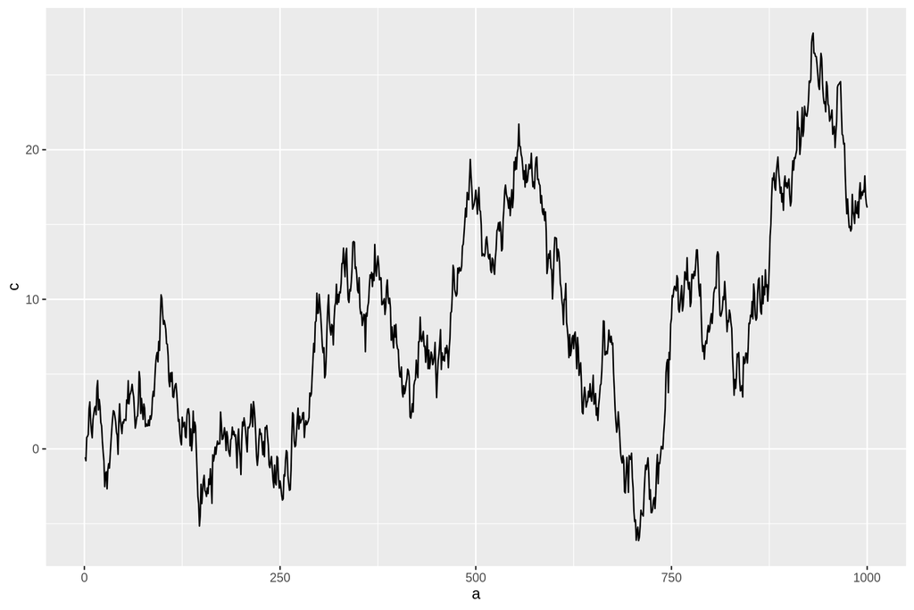

```r
aa <- data.frame(a = c(1:1000))

# Generate a random walk
set.seed(123)
aa$b <- rnorm(1000)
aa$c <- cumsum(aa$b)

# Plot the random walk
ggplot(aa, aes(x = a, y = c)) + geom_path()
```

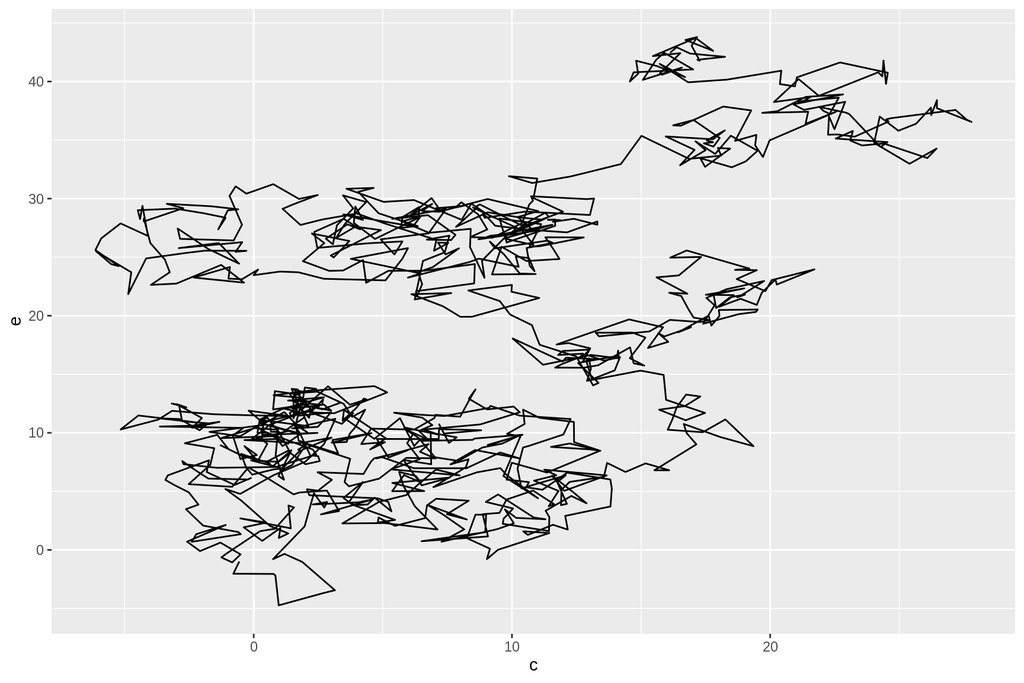

```r
# Generate another random walk
aa$d <- rnorm(1000)
aa$e <- cumsum(aa$d)

# Plot the 2D random walk
ggplot(aa, aes(x = c, y = e)) + geom_path()
```

```r
# Any correlation
m1 <- lm(c ~ e, data = aa)
summary(m1)
```

```
##
## Call:
## lm(formula = c ~ e, data = aa)
##
## Residuals:
##      Min       1Q   Median       3Q      Max
## -16.7193  -4.3469  -0.2624   5.2217  14.1622
##
## Coefficients:
##             Estimate Std. Error t value Pr(>|t|)
## (Intercept)   2.3850     0.3652    6.53 1.05e-10 ***
## e             0.3168     0.0173   18.31  < 2e-16 ***
## ---
## Signif. codes:  0 '***' 0.001 '**' 0.01 '*' 0.05 '.' 0.1 ' ' 1
##
## Residual standard error: 6.309 on 998 degrees of freedom
## Multiple R-squared:  0.2515, Adjusted R-squared:  0.2508
## F-statistic: 335.4 on 1 and 998 DF,  p-value: < 2.2e-16
```

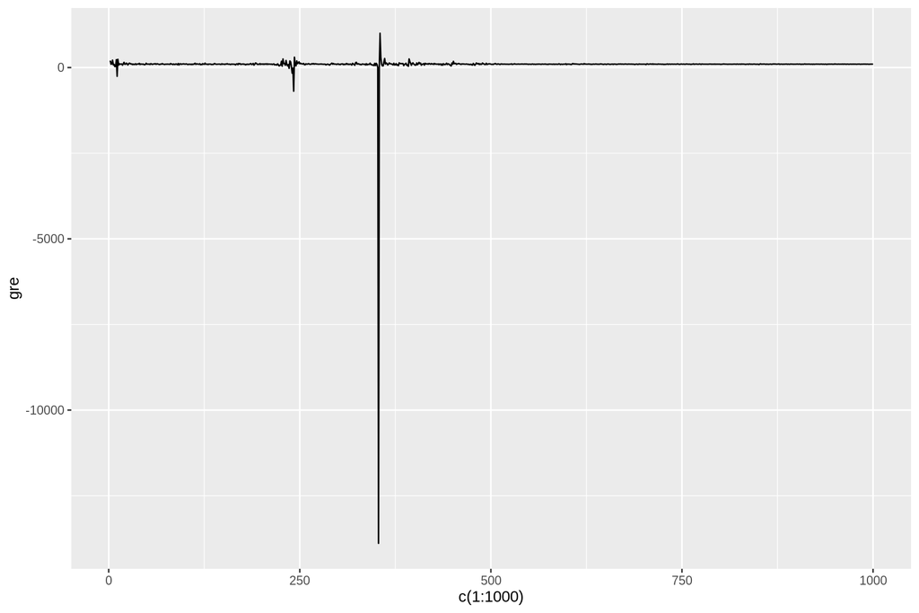

```r
# Calculate growth rate of e
aa$gre <- c(NA, 100 * (aa$e[2:1000] / aa$e[1:999]) - 1)
ggplot(aa, aes(x = c(1:1000), y = gre)) + geom_path()
```

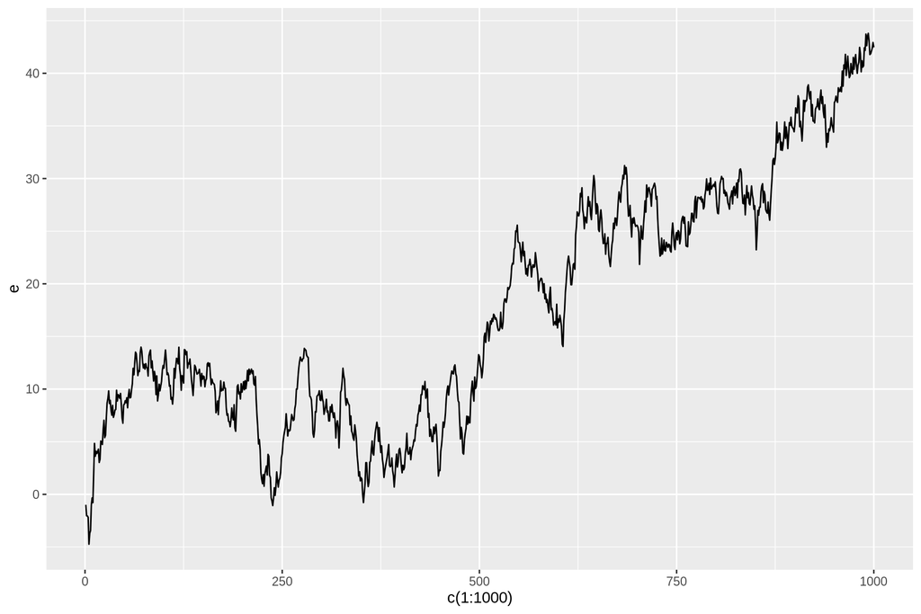

```r
ggplot(aa, aes(x = c(1:1000), y = e)) + geom_path()
```

## Data operations

- Create a data set (data table)
- Filter a data table down to the rows and columns of interest
- Clean its values with arithmetic and string operations
- Summarize groups of rows (conditional on something)
- Compute new columns (variables) based on existing columns
- Join a data table with others, for further analysis
- Plot one variable vs. another (in many different ways)
- Model one variable as a function of others (for example, linear regression)

## Data table operations

- DT[ i, j, by ]
  - Take **DT**
  - subset rows using **i**,
  - then calculate **j**
  - grouped by **by**

## Data table operations

- Create a firm level data set

```r
# Empty the global environment
rm(list=ls())

# Parameters
nf <- 1000
nt <- 20
ns <- 10
nobs <- nf*nt

kelas <- 0.1
lelas <- 0.2
melas <- 0.75

id <- rep(c(1:nf), each = nt)
year <- rep(c(1:nt), times = nf)
sect <- rep(c(1:ns), each = nobs / ns)
kg <- rnorm(nobs, 0.01, 0.02)
lg <- (kg/10) + rnorm(nobs, 0.01, 0.01)
mg <- (lg/10) + rnorm(nobs, 0.005, 0.01)
tc <- rnorm(nobs, 0.01, 0.01)
fs <- max(0.1, rep(rnorm(nf, 2, 0.5), each = nt))
re <- max(0.1, rep(rnorm(nf, 0, 0.5), each = nt))
ee <- rnorm(nobs, 0, 0.1)

# Data table
fdata <- data.table(id, year, sect, kg, lg, mg, tc, fs, re, ee)
fdata[, lk := fs*(1 + cumsum(kg)), by = id]
fdata[, ll := fs*(1 + cumsum(lg)), by = id]
fdata[, lm := fs*(1 + cumsum(mg)), by = id]
fdata[, lA := fs*(1 + cumsum(tc)), by = id]
fdata[, fe := max(0.1, rep(rnorm(nf, 0, 0.5)) + mean(lk)/5 + mean(ll)/5), by = id]
fdata[, lq := re + (lA + kelas*lk + lelas*ll + melas*lm) + ee]
rm(nf, nt, ns, nobs, kelas, lelas, melas, id, year, sect, kg, lg, mg,
       tc, fs, re, ee)
```

## Analyze the data set

```r
# Basic statistics
class(fdata)
```

```
## [1] "data.table" "data.frame"
```

```r
names(fdata)
```

```
##  [1] "id"   "year" "sect" "kg"   "lg"   "mg"   "tc"   "fs"   "re"   "ee"
## [11] "lk"   "ll"   "lm"   "lA"   "fe"   "lq"
```

```r
head(fdata)
```

```
##    id year sect            kg           lg            mg          tc
## 1:  1    1    1 -0.0002320744 -0.022823040 -0.0059726355 0.004636073
## 2:  1    2    1  0.0147387576  0.012889209  0.0007184099 0.021840268
## 3:  1    3    1 -0.0008317834 -0.003767392  0.0144581771 0.009797892
## 4:  1    4    1  0.0343845529  0.006160969  0.0025308890 0.007914230
## 5:  1    5    1  0.0134827175  0.010668339  0.0073971701 0.015954826
## 6:  1    6    1 -0.0023053663  0.014908510  0.0077967036 0.004953235
##          fs       re          ee       lk       ll       lm       lA
## 1: 3.863068 1.549448  0.13122076 3.862172 3.774901 3.839995 3.880978
## 2: 3.863068 1.549448  0.04699733 3.919108 3.824693 3.842771 3.965348
## 3: 3.863068 1.549448  0.15445384 3.915895 3.810139 3.898624 4.003198
## 4: 3.863068 1.549448  0.08272013 4.048725 3.833940 3.908401 4.033771
## 5: 3.863068 1.549448 -0.04270201 4.100810 3.875152 3.936976 4.095406
## 6: 3.863068 1.549448 -0.17411472 4.091904 3.932745 3.967096 4.114540
##          fe       lq
## 1: 3.068317 9.582840
## 2: 3.068317 9.600721
## 3: 3.068317 9.784685
## 4: 3.068317 9.768900
## 5: 3.068317 9.739995
## 6: 3.068317 9.660935
```

```r
str(fdata)
```

```
## Classes 'data.table' and 'data.frame':   20000 obs. of  16 variables:
##  $ id  : int  1 1 1 1 1 1 1 1 1 1 ...
##  $ year: int  1 2 3 4 5 6 7 8 9 10 ...
##  $ sect: int  1 1 1 1 1 1 1 1 1 1 ...
##  $ kg  : num  -0.000232 0.014739 -0.000832 0.034385 0.013483 ...
##  $ lg  : num  -0.02282 0.01289 -0.00377 0.00616 0.01067 ...
##  $ mg  : num  -0.005973 0.000718 0.014458 0.002531 0.007397 ...
##  $ tc  : num  0.00464 0.02184 0.0098 0.00791 0.01595 ...
##  $ fs  : num  3.86 3.86 3.86 3.86 3.86 ...
##  $ re  : num  1.55 1.55 1.55 1.55 1.55 ...
##  $ ee  : num  0.1312 0.047 0.1545 0.0827 -0.0427 ...
##  $ lk  : num  3.86 3.92 3.92 4.05 4.1 ...
##  $ ll  : num  3.77 3.82 3.81 3.83 3.88 ...
##  $ lm  : num  3.84 3.84 3.9 3.91 3.94 ...
##  $ lA  : num  3.88 3.97 4 4.03 4.1 ...
##  $ fe  : num  3.07 3.07 3.07 3.07 3.07 ...
##  $ lq  : num  9.58 9.6 9.78 9.77 9.74 ...
##  - attr(*, ".internal.selfref")=<externalptr>
```

```r
summary(fdata)
```

```
##        id              year            sect            kg
##  Min.   :   1.0   Min.   : 1.00   Min.   : 1.0   Min.   :-0.066906
##  1st Qu.: 250.8   1st Qu.: 5.75   1st Qu.: 3.0   1st Qu.:-0.003536
##  Median : 500.5   Median :10.50   Median : 5.5   Median : 0.009693
##  Mean   : 500.5   Mean   :10.50   Mean   : 5.5   Mean   : 0.009808
##  3rd Qu.: 750.2   3rd Qu.:15.25   3rd Qu.: 8.0   3rd Qu.: 0.023310
##  Max.   :1000.0   Max.   :20.00   Max.   :10.0   Max.   : 0.088428
##        lg                  mg                   tc
##  Min.   :-0.030734   Min.   :-0.0312275   Min.   :-0.029682
##  1st Qu.: 0.004022   1st Qu.:-0.0006562   1st Qu.: 0.003516
##  Median : 0.010873   Median : 0.0061980   Median : 0.010156
##  Mean   : 0.010931   Mean   : 0.0061835   Mean   : 0.010122
##  3rd Qu.: 0.017872   3rd Qu.: 0.0129005   3rd Qu.: 0.016868
##  Max.   : 0.051246   Max.   : 0.0437439   Max.   : 0.048689
##        fs              re              ee                   lk
##  Min.   :3.863   Min.   :1.549   Min.   :-0.4132090   Min.   :3.324
##  1st Qu.:3.863   1st Qu.:1.549   1st Qu.:-0.0671504   1st Qu.:4.004
##  Median :3.863   Median :1.549   Median :-0.0004495   Median :4.214
##  Mean   :3.863   Mean   :1.549   Mean   :-0.0005325   Mean   :4.261
##  3rd Qu.:3.863   3rd Qu.:1.549   3rd Qu.: 0.0662047   3rd Qu.:4.479
##  Max.   :3.863   Max.   :1.549   Max.   : 0.4206090   Max.   :5.566
##        ll              lm              lA              fe
##  Min.   :3.741   Min.   :3.645   Min.   :3.726   Min.   :2.862
##  1st Qu.:4.076   1st Qu.:3.962   1st Qu.:4.061   1st Qu.:3.202
##  Median :4.286   Median :4.093   Median :4.259   Median :3.310
##  Mean   :4.305   Mean   :4.113   Mean   :4.274   Mean   :3.330
##  3rd Qu.:4.510   3rd Qu.:4.238   3rd Qu.:4.464   3rd Qu.:3.435
##  Max.   :5.208   Max.   :4.881   Max.   :5.201   Max.   :4.195
##        lq
##  Min.   : 9.124
##  1st Qu.: 9.831
##  Median :10.177
##  Mean   :10.196
##  3rd Qu.:10.539
##  Max.   :11.698
```

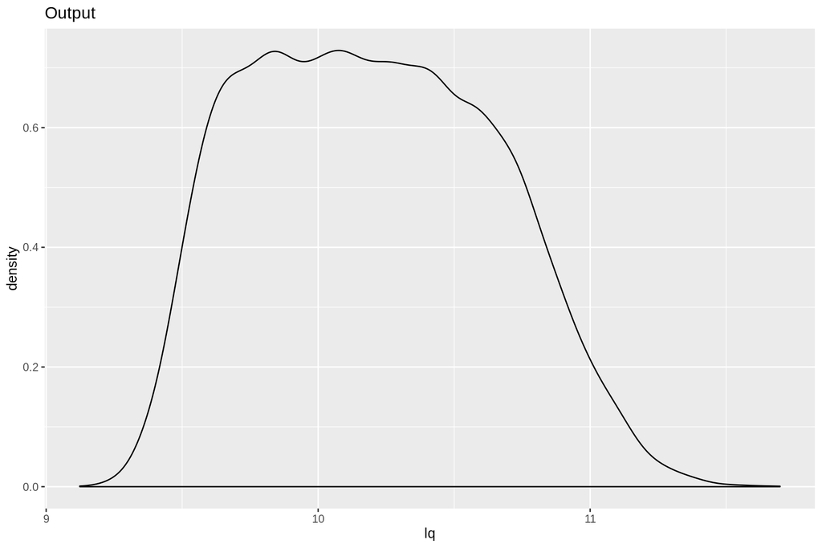

```r
# Check outliers
ggplot(fdata, aes(x = lq)) + geom_density() + labs(title = "Output")
```

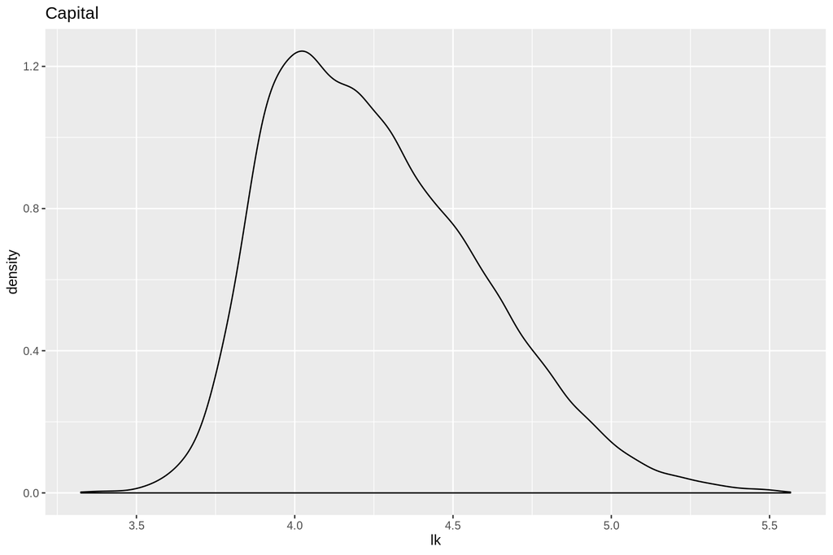

```r
ggplot(fdata, aes(x = lk)) + geom_density() + labs(title = "Capital")
```

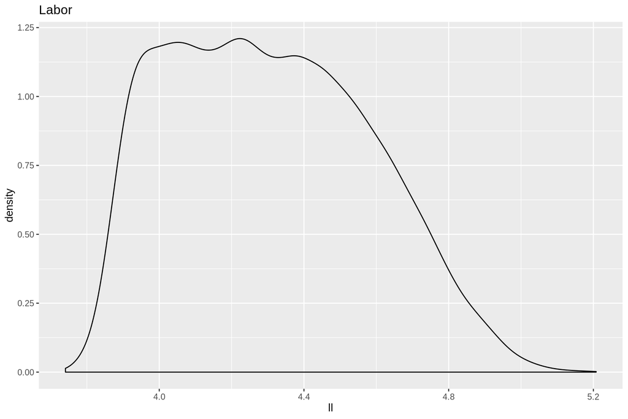

```r
ggplot(fdata, aes(x = ll)) + geom_density() + labs(title = "Labor")
```

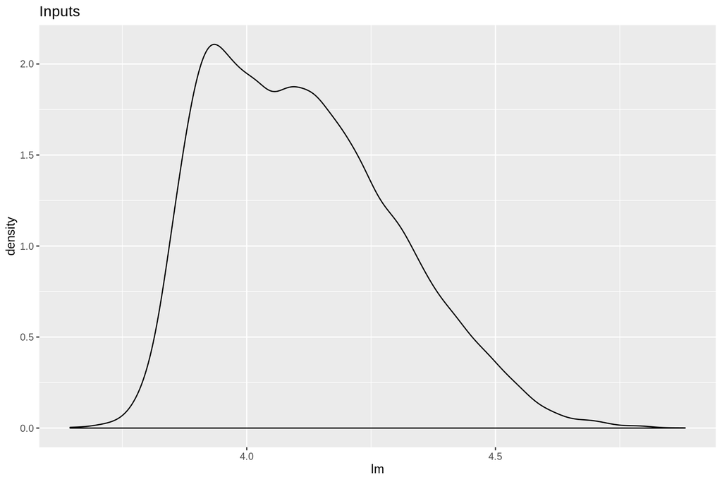

```r
ggplot(fdata, aes(x = lm)) + geom_density() + labs(title = "Inputs")
```

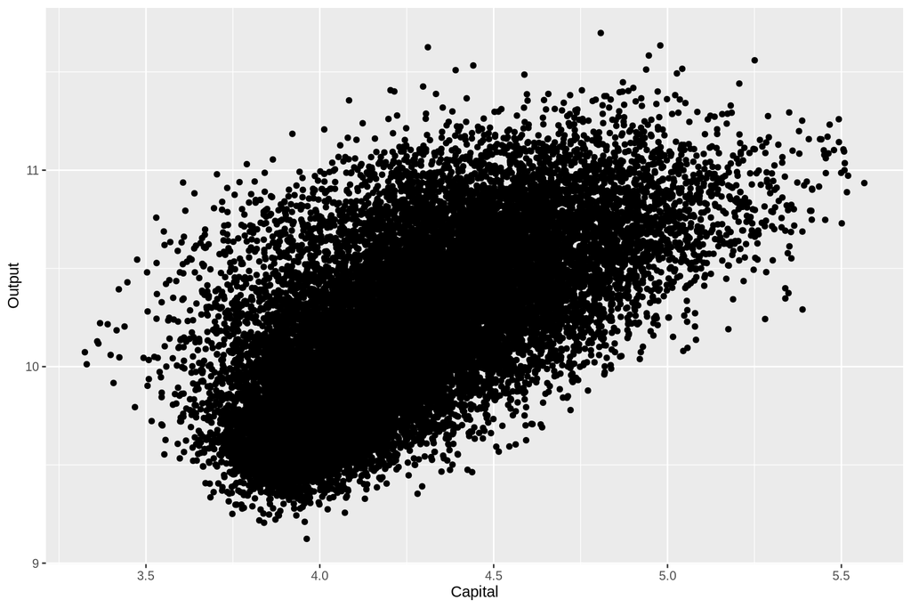

```r
# Check correlations
ggplot(fdata, aes(x = lk, y = lq)) + geom_point() +
  labs(x = "Capital", y = "Output")
```

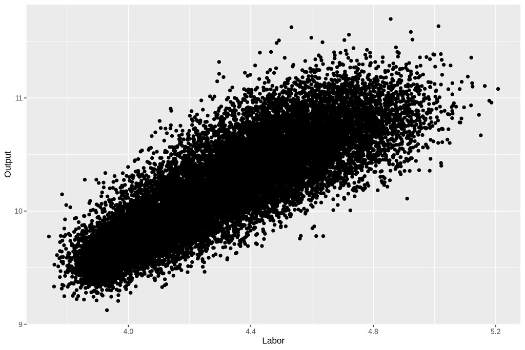

```r
ggplot(fdata, aes(x = ll, y = lq)) + geom_point() +
  labs(x = "Labor", y = "Output")
```

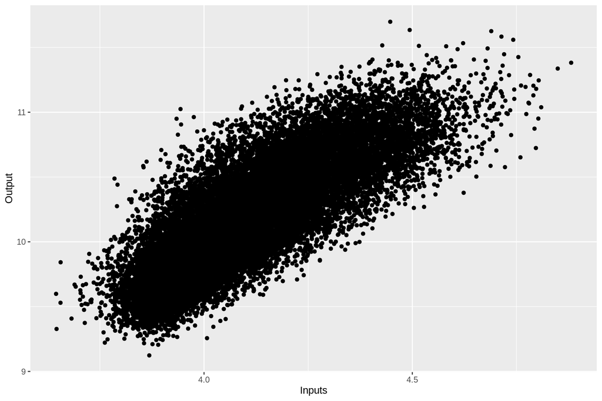

```r
ggplot(fdata, aes(x = lm, y = lq)) + geom_point() +
  labs(x = "Inputs", y = "Output")
```

## Deleting variables

```r
# One variable
names(fdata)
```

```
##  [1] "id"   "year" "sect" "kg"   "lg"   "mg"   "tc"   "fs"   "re"   "ee"
## [11] "lk"   "ll"   "lm"   "lA"   "fe"   "lq"
```

```r
fdata[, kg := NULL]
names(fdata)
```

```
##  [1] "id"   "year" "sect" "lg"   "mg"   "tc"   "fs"   "re"   "ee"   "lk"
## [11] "ll"   "lm"   "lA"   "fe"   "lq"
```

```r
# Many variables
fdata[, c("lg", "mg", "tc", "fs", "fe", "ee") := NULL]
names(fdata)
```

```
## [1] "id"   "year" "sect" "re"   "lk"   "ll"   "lm"   "lA"   "lq"
```

## Subsetting rows

- Observations are in rows

```r
# Rows 3-5
fdata[3:5,]
```

```
##    id year sect       re       lk       ll       lm       lA       lq
## 1:  1    3    1 1.549448 3.915895 3.810139 3.898624 4.003198 9.784685
## 2:  1    4    1 1.549448 4.048725 3.833940 3.908401 4.033771 9.768900
## 3:  1    5    1 1.549448 4.100810 3.875152 3.936976 4.095406 9.739995
```

```r
fdata[3:5]
```

```
##    id year sect       re       lk       ll       lm       lA       lq
## 1:  1    3    1 1.549448 3.915895 3.810139 3.898624 4.003198 9.784685
## 2:  1    4    1 1.549448 4.048725 3.833940 3.908401 4.033771 9.768900
## 3:  1    5    1 1.549448 4.100810 3.875152 3.936976 4.095406 9.739995
```

```r
# Rows other than 3-5
fdata[-(3:5)]
```

```
##          id year sect       re       lk       ll       lm       lA
##     1:    1    1    1 1.549448 3.862172 3.774901 3.839995 3.880978
##     2:    1    2    1 1.549448 3.919108 3.824693 3.842771 3.965348
##     3:    1    6    1 1.549448 4.091904 3.932745 3.967096 4.114540
##     4:    1    7    1 1.549448 3.990932 3.992303 4.025372 4.091948
##     5:    1    8    1 1.549448 3.979831 4.035224 4.067952 4.101471
##    ---
## 19993: 1000   16   10 1.549448 4.226719 4.150365 4.233986 4.389690
## 19994: 1000   17   10 1.549448 4.290319 4.176399 4.264723 4.341451
## 19995: 1000   18   10 1.549448 4.230260 4.141397 4.290881 4.371437
## 19996: 1000   19   10 1.549448 4.217664 4.239751 4.397182 4.361404
## 19997: 1000   20   10 1.549448 4.156285 4.269480 4.404235 4.381244
##               lq
##     1:  9.582840
##     2:  9.600721
##     3:  9.660935
##     4:  9.674646
##     5:  9.817215
##    ---
## 19993: 10.304541
## 19994: 10.431146
## 19995: 10.230929
## 19996: 10.529978
## 19997: 10.484083
```

```r
fdata[!3:5]
```

```
##          id year sect       re       lk       ll       lm       lA
##     1:    1    1    1 1.549448 3.862172 3.774901 3.839995 3.880978
##     2:    1    2    1 1.549448 3.919108 3.824693 3.842771 3.965348
##     3:    1    6    1 1.549448 4.091904 3.932745 3.967096 4.114540
##     4:    1    7    1 1.549448 3.990932 3.992303 4.025372 4.091948
##     5:    1    8    1 1.549448 3.979831 4.035224 4.067952 4.101471
##    ---
## 19993: 1000   16   10 1.549448 4.226719 4.150365 4.233986 4.389690
## 19994: 1000   17   10 1.549448 4.290319 4.176399 4.264723 4.341451
## 19995: 1000   18   10 1.549448 4.230260 4.141397 4.290881 4.371437
## 19996: 1000   19   10 1.549448 4.217664 4.239751 4.397182 4.361404
## 19997: 1000   20   10 1.549448 4.156285 4.269480 4.404235 4.381244
##               lq
##     1:  9.582840
##     2:  9.600721
##     3:  9.660935
##     4:  9.674646
##     5:  9.817215
##    ---
## 19993: 10.304541
## 19994: 10.431146
## 19995: 10.230929
## 19996: 10.529978
## 19997: 10.484083
```

```r
# Rows conditional on variable values
fdata[lq >= 10]
```

```
##          id year sect       re       lk       ll       lm       lA
##     1:    1    9    1 1.549448 4.176540 4.082325 4.095582 4.157613
##     2:    1   10    1 1.549448 4.171845 4.105331 4.115125 4.252260
##     3:    1   11    1 1.549448 4.145885 4.137243 4.094832 4.277519
##     4:    1   12    1 1.549448 4.234963 4.160947 4.185049 4.271940
##     5:    1   13    1 1.549448 4.307689 4.215517 4.193729 4.366108
##    ---
## 12574: 1000   16   10 1.549448 4.226719 4.150365 4.233986 4.389690
## 12575: 1000   17   10 1.549448 4.290319 4.176399 4.264723 4.341451
## 12576: 1000   18   10 1.549448 4.230260 4.141397 4.290881 4.371437
## 12577: 1000   19   10 1.549448 4.217664 4.239751 4.397182 4.361404
## 12578: 1000   20   10 1.549448 4.156285 4.269480 4.404235 4.381244
##              lq
##     1: 10.10790
##     2: 10.21832
##     3: 10.06598
##     4: 10.36843
##     5: 10.18135
##    ---
## 12574: 10.30454
## 12575: 10.43115
## 12576: 10.23093
## 12577: 10.52998
## 12578: 10.48408
```

```r
fdata[lq >= 10 & ll <= 4]
```

```
##       id year sect       re       lk       ll       lm       lA       lq
##  1:   22    8    1 1.549448 3.964360 3.943044 4.166672 4.147934 10.04763
##  2:   22    9    1 1.549448 3.907169 3.959647 4.138709 4.318437 10.18808
##  3:   22   10    1 1.549448 3.994934 3.984031 4.178632 4.338461 10.14727
##  4:   44    3    1 1.549448 3.929529 3.921664 3.957233 4.074655 10.01993
##  5:   44   10    1 1.549448 4.292750 3.986652 3.939943 4.250642 10.07869
##  6:   48    6    1 1.549448 4.337953 3.926515 3.911822 4.158060 10.05402
##  7:   60    5    1 1.549448 4.286924 3.980216 3.957640 4.127286 10.03818
##  8:   66    5    1 1.549448 4.103973 3.964526 3.989679 4.168325 10.03675
##  9:   81    5    1 1.549448 4.160035 3.983833 4.047617 4.100158 10.03234
## 10:   84    6    1 1.549448 4.090370 3.937021 3.904897 4.279514 10.09745
## 11:   86    7    1 1.549448 4.108229 3.958409 4.072148 4.156292 10.01233
## 12:   86    8    1 1.549448 4.127602 3.992879 4.134535 4.203489 10.11454
## 13:   86    9    1 1.549448 4.150056 3.998646 4.111365 4.266858 10.11756
## 14:  104    5    2 1.549448 4.087900 3.984045 3.970657 4.205672 10.02807
```

[output cut: 86 more lines]

```r
fdata[lq >= 10 && ll <= 4]
```

```
## Empty data.table (0 rows) of 9 cols: id,year,sect,re,lk,ll...
```

```r
fdata[lq >= 10 | ll <= 4]
```

```
##          id year sect       re       lk       ll       lm       lA
##     1:    1    1    1 1.549448 3.862172 3.774901 3.839995 3.880978
##     2:    1    2    1 1.549448 3.919108 3.824693 3.842771 3.965348
##     3:    1    3    1 1.549448 3.915895 3.810139 3.898624 4.003198
##     4:    1    4    1 1.549448 4.048725 3.833940 3.908401 4.033771
##     5:    1    5    1 1.549448 4.100810 3.875152 3.936976 4.095406
##    ---
## 15645: 1000   16   10 1.549448 4.226719 4.150365 4.233986 4.389690
## 15646: 1000   17   10 1.549448 4.290319 4.176399 4.264723 4.341451
## 15647: 1000   18   10 1.549448 4.230260 4.141397 4.290881 4.371437
## 15648: 1000   19   10 1.549448 4.217664 4.239751 4.397182 4.361404
## 15649: 1000   20   10 1.549448 4.156285 4.269480 4.404235 4.381244
##               lq
##     1:  9.582840
##     2:  9.600721
##     3:  9.784685
##     4:  9.768900
##     5:  9.739995
##    ---
## 15645: 10.304541
## 15646: 10.431146
## 15647: 10.230929
## 15648: 10.529978
## 15649: 10.484083
```

```r
# All rows where id == 1
fdata[id == 1]
```

```
##     id year sect       re       lk       ll       lm       lA        lq
##  1:  1    1    1 1.549448 3.862172 3.774901 3.839995 3.880978  9.582840
##  2:  1    2    1 1.549448 3.919108 3.824693 3.842771 3.965348  9.600721
##  3:  1    3    1 1.549448 3.915895 3.810139 3.898624 4.003198  9.784685
##  4:  1    4    1 1.549448 4.048725 3.833940 3.908401 4.033771  9.768900
##  5:  1    5    1 1.549448 4.100810 3.875152 3.936976 4.095406  9.739995
##  6:  1    6    1 1.549448 4.091904 3.932745 3.967096 4.114540  9.660935
##  7:  1    7    1 1.549448 3.990932 3.992303 4.025372 4.091948  9.674646
##  8:  1    8    1 1.549448 3.979831 4.035224 4.067952 4.101471  9.817215
##  9:  1    9    1 1.549448 4.176540 4.082325 4.095582 4.157613 10.107900
## 10:  1   10    1 1.549448 4.171845 4.105331 4.115125 4.252260 10.218320
## 11:  1   11    1 1.549448 4.145885 4.137243 4.094832 4.277519 10.065978
## 12:  1   12    1 1.549448 4.234963 4.160947 4.185049 4.271940 10.368427
## 13:  1   13    1 1.549448 4.307689 4.215517 4.193729 4.366108 10.181351
## 14:  1   14    1 1.549448 4.404392 4.255034 4.242622 4.382836 10.384899
## 15:  1   15    1 1.549448 4.421546 4.344362 4.316797 4.432053 10.594560
## 16:  1   16    1 1.549448 4.546914 4.359401 4.330609 4.486893 10.689910
## 17:  1   17    1 1.549448 4.494947 4.326558 4.309247 4.536981 10.516520
## 18:  1   18    1 1.549448 4.529802 4.452499 4.365506 4.592035 10.783428
## 19:  1   19    1 1.549448 4.514030 4.441219 4.367828 4.617422 10.670061
## 20:  1   20    1 1.549448 4.605257 4.494579 4.411256 4.681515 10.925218
```

```r
setkey(fdata, id, year)
fdata[list(1)]
```

```
##     id year sect       re       lk       ll       lm       lA        lq
##  1:  1    1    1 1.549448 3.862172 3.774901 3.839995 3.880978  9.582840
##  2:  1    2    1 1.549448 3.919108 3.824693 3.842771 3.965348  9.600721
##  3:  1    3    1 1.549448 3.915895 3.810139 3.898624 4.003198  9.784685
##  4:  1    4    1 1.549448 4.048725 3.833940 3.908401 4.033771  9.768900
##  5:  1    5    1 1.549448 4.100810 3.875152 3.936976 4.095406  9.739995
##  6:  1    6    1 1.549448 4.091904 3.932745 3.967096 4.114540  9.660935
##  7:  1    7    1 1.549448 3.990932 3.992303 4.025372 4.091948  9.674646
##  8:  1    8    1 1.549448 3.979831 4.035224 4.067952 4.101471  9.817215
##  9:  1    9    1 1.549448 4.176540 4.082325 4.095582 4.157613 10.107900
## 10:  1   10    1 1.549448 4.171845 4.105331 4.115125 4.252260 10.218320
## 11:  1   11    1 1.549448 4.145885 4.137243 4.094832 4.277519 10.065978
## 12:  1   12    1 1.549448 4.234963 4.160947 4.185049 4.271940 10.368427
## 13:  1   13    1 1.549448 4.307689 4.215517 4.193729 4.366108 10.181351
## 14:  1   14    1 1.549448 4.404392 4.255034 4.242622 4.382836 10.384899
## 15:  1   15    1 1.549448 4.421546 4.344362 4.316797 4.432053 10.594560
## 16:  1   16    1 1.549448 4.546914 4.359401 4.330609 4.486893 10.689910
## 17:  1   17    1 1.549448 4.494947 4.326558 4.309247 4.536981 10.516520
## 18:  1   18    1 1.549448 4.529802 4.452499 4.365506 4.592035 10.783428
## 19:  1   19    1 1.549448 4.514030 4.441219 4.367828 4.617422 10.670061
## 20:  1   20    1 1.549448 4.605257 4.494579 4.411256 4.681515 10.925218
```

```r
fdata[list(c(1:2), c(10,20)), list(id, year, sect, lq)]
```

```
##    id year sect       lq
## 1:  1   10    1 10.21832
## 2:  2   20    1 10.98291
```

```r
fdata[(id %in% c(1,2)) & (year %in% c(10, 20))]
```

```
##    id year sect       re       lk       ll       lm       lA       lq
## 1:  1   10    1 1.549448 4.171845 4.105331 4.115125 4.252260 10.21832
## 2:  1   20    1 1.549448 4.605257 4.494579 4.411256 4.681515 10.92522
## 3:  2   10    1 1.549448 4.451089 4.262958 4.041126 4.245163 10.05635
## 4:  2   20    1 1.549448 4.918969 4.646606 4.350668 4.648884 10.98291
```

```r
fdata[list(c(1:2))][year %in% c(10, 20)]
```

```
##    id year sect       re       lk       ll       lm       lA       lq
## 1:  1   10    1 1.549448 4.171845 4.105331 4.115125 4.252260 10.21832
## 2:  1   20    1 1.549448 4.605257 4.494579 4.411256 4.681515 10.92522
## 3:  2   10    1 1.549448 4.451089 4.262958 4.041126 4.245163 10.05635
## 4:  2   20    1 1.549448 4.918969 4.646606 4.350668 4.648884 10.98291
```

```r
sM <- data.table(id=c(1,1,2,2), year=c(10,20,10,20))
sM
```

```
##    id year
## 1:  1   10
## 2:  1   20
## 3:  2   10
## 4:  2   20
```

```r
fdata[sM]
```

```
##    id year sect       re       lk       ll       lm       lA       lq
## 1:  1   10    1 1.549448 4.171845 4.105331 4.115125 4.252260 10.21832
## 2:  1   20    1 1.549448 4.605257 4.494579 4.411256 4.681515 10.92522
## 3:  2   10    1 1.549448 4.451089 4.262958 4.041126 4.245163 10.05635
## 4:  2   20    1 1.549448 4.918969 4.646606 4.350668 4.648884 10.98291
```

## Selecting and computing columns

- Variables are in columns

```r
# Column id
fdata[, id]
```

```
##     [1]    1    1    1    1    1    1    1    1    1    1    1    1    1
##    [14]    1    1    1    1    1    1    1    2    2    2    2    2    2
##    [27]    2    2    2    2    2    2    2    2    2    2    2    2    2
##    [40]    2    3    3    3    3    3    3    3    3    3    3    3    3
##    [53]    3    3    3    3    3    3    3    3    4    4    4    4    4
##    [66]    4    4    4    4    4    4    4    4    4    4    4    4    4
##    [79]    4    4    5    5    5    5    5    5    5    5    5    5    5
##    [92]    5    5    5    5    5    5    5    5    5    6    6    6    6
##   [105]    6    6    6    6    6    6    6    6    6    6    6    6    6
##   [118]    6    6    6    7    7    7    7    7    7    7    7    7    7
##   [131]    7    7    7    7    7    7    7    7    7    7    8    8    8
##   [144]    8    8    8    8    8    8    8    8    8    8    8    8    8
##   [157]    8    8    8    8    9    9    9    9    9    9    9    9    9
##   [170]    9    9    9    9    9    9    9    9    9    9    9   10   10
##   [183]   10   10   10   10   10   10   10   10   10   10   10   10   10
```

[output cut: 1524 more lines]

```r
fdata[, list(id)]
```

```
##          id
##     1:    1
##     2:    1
##     3:    1
##     4:    1
##     5:    1
##    ---
## 19996: 1000
## 19997: 1000
## 19998: 1000
## 19999: 1000
## 20000: 1000
```

```r
fdata[, .(id)]
```

```
##          id
##     1:    1
##     2:    1
##     3:    1
##     4:    1
##     5:    1
##    ---
## 19996: 1000
## 19997: 1000
## 19998: 1000
## 19999: 1000
## 20000: 1000
```

```r
# Columns id, year and lq
fdata[, list(id, year, lq)]
```

```
##          id year        lq
##     1:    1    1  9.582840
##     2:    1    2  9.600721
##     3:    1    3  9.784685
##     4:    1    4  9.768900
##     5:    1    5  9.739995
##    ---
## 19996: 1000   16 10.304541
## 19997: 1000   17 10.431146
## 19998: 1000   18 10.230929
## 19999: 1000   19 10.529978
## 20000: 1000   20 10.484083
```

```r
fdata[, .(id, year, lq)]
```

```
##          id year        lq
##     1:    1    1  9.582840
##     2:    1    2  9.600721
##     3:    1    3  9.784685
##     4:    1    4  9.768900
##     5:    1    5  9.739995
##    ---
## 19996: 1000   16 10.304541
## 19997: 1000   17 10.431146
## 19998: 1000   18 10.230929
## 19999: 1000   19 10.529978
## 20000: 1000   20 10.484083
```

```r
# Computing columns
fdata[, mean(lq)]
```

```
## [1] 10.19558
```

```r
fdata[, list(mean(lq))]
```

```
##          V1
## 1: 10.19558
```

```r
fdata[, list(mean(lq), sd(lq))]
```

```
##          V1        V2
## 1: 10.19558 0.4421356
```

```r
fdata[, list(mean(lq), mean(ll))]
```

```
##          V1       V2
## 1: 10.19558 4.304935
```

```r
# Assigning names to computed columns
fdata[, list(mean_lq = mean(lq), sd_lq = sd(lq))]
```

```
##     mean_lq     sd_lq
## 1: 10.19558 0.4421356
```

## Selecting rows and columns

```r
# Rows 3-5 of column id
fdata[3:5, id]
```

```
## [1] 1 1 1
```

```r
# Rows 3-5 of columns id, year and lq
fdata[3:5, .(id, year, lq)]
```

```
##    id year       lq
## 1:  1    3 9.784685
## 2:  1    4 9.768900
## 3:  1    5 9.739995
```

```r
# id, year, lq and lk for missing lk's
fdata[is.na(lk), .(id, year, lq, lk)]
```

```
## Empty data.table (0 rows) of 4 cols: id,year,lq,lk
```

```r
# First 10 rows of id, year, lq and lk for missing lk's
fdata[is.na(lk), .(id, year, lq, lk)][1:10]
```

```
##     id year lq lk
##  1: NA   NA NA NA
##  2: NA   NA NA NA
##  3: NA   NA NA NA
##  4: NA   NA NA NA
##  5: NA   NA NA NA
##  6: NA   NA NA NA
##  7: NA   NA NA NA
##  8: NA   NA NA NA
##  9: NA   NA NA NA
## 10: NA   NA NA NA
```

## Rows and columns by groups

```r
# Doing j by group
sectq <- fdata[, list(mean.lq = mean(lq), sd.lq = sd(lq)), by = sect]
sectq
```

```
##     sect  mean.lq     sd.lq
##  1:    1 10.19695 0.4469915
##  2:    2 10.18742 0.4377487
##  3:    3 10.20416 0.4448391
##  4:    4 10.19486 0.4443234
##  5:    5 10.21022 0.4410429
##  6:    6 10.19225 0.4353711
##  7:    7 10.18851 0.4326625
##  8:    8 10.17703 0.4432725
##  9:    9 10.20973 0.4429429
## 10:   10 10.19466 0.4517431
```

```r
# Doing j by several groups
sectq <- fdata[, list(mean.lq = mean(lq), sd.lq = sd(lq)),
               by = list(sect, year)]
sectq
```

```
##      sect year   mean.lq     sd.lq
##   1:    1    1  9.531483 0.1094064
##   2:    1    2  9.610779 0.1267184
##   3:    1    3  9.659092 0.1335480
##   4:    1    4  9.736916 0.1424732
##   5:    1    5  9.816365 0.1543937
##  ---
## 196:   10   16 10.593747 0.2533653
## 197:   10   17 10.641686 0.2507292
## 198:   10   18 10.712511 0.2542738
## 199:   10   19 10.783951 0.2658066
## 200:   10   20 10.854523 0.2803954
```

```r
# Call functions in by
fdata[, list(mean.lq = mean(lq), sd.lq = sd(lq)), by = list(year>5)]
```

```
##     year   mean.lq     sd.lq
## 1: FALSE  9.674969 0.1624902
## 2:  TRUE 10.369114 0.3624671
```

```r
fdata[, list(mean.lq = mean(lq), sd.lq = sd(lq)), by = list(sect, year>5)]
```

```
##     sect  year   mean.lq     sd.lq
##  1:    1 FALSE  9.670927 0.1661829
##  2:    1  TRUE 10.372284 0.3663270
##  3:    2 FALSE  9.663978 0.1597828
##  4:    2  TRUE 10.361894 0.3538207
##  5:    3 FALSE  9.675822 0.1600963
##  6:    3  TRUE 10.380271 0.3622282
##  7:    4 FALSE  9.676876 0.1681837
##  8:    4  TRUE 10.367524 0.3667846
##  9:    5 FALSE  9.684569 0.1638380
## 10:    5  TRUE 10.385431 0.3571861
## 11:    6 FALSE  9.684314 0.1621445
## 12:    6  TRUE 10.361562 0.3595526
## 13:    7 FALSE  9.680890 0.1576551
## 14:    7  TRUE 10.357717 0.3560383
## 15:    8 FALSE  9.654526 0.1622511
## 16:    8  TRUE 10.351193 0.3631124
## 17:    9 FALSE  9.688940 0.1645010
## 18:    9  TRUE 10.383332 0.3633289
## 19:   10 FALSE  9.668854 0.1583017
## 20:   10  TRUE 10.369933 0.3752853
```

```r
# Grouping only on a subset
fdata[1:5, list(mean.lq = mean(lq), sd.lq = sd(lq)), by= year]
```

```
##    year  mean.lq sd.lq
## 1:    1 9.582840    NA
## 2:    2 9.600721    NA
## 3:    3 9.784685    NA
## 4:    4 9.768900    NA
## 5:    5 9.739995    NA
```

```r
# Using .N to get the total number of observations
fdata[!is.na(lk), .N, by = sect]
```

```
##     sect    N
##  1:    1 2000
##  2:    2 2000
##  3:    3 2000
##  4:    4 2000
##  5:    5 2000
##  6:    6 2000
##  7:    7 2000
##  8:    8 2000
##  9:    9 2000
## 10:   10 2000
```

```r
fdata[!is.na(lk), .N, keyby = sect]
```

```
##     sect    N
##  1:    1 2000
##  2:    2 2000
##  3:    3 2000
##  4:    4 2000
##  5:    5 2000
##  6:    6 2000
##  7:    7 2000
##  8:    8 2000
##  9:    9 2000
## 10:   10 2000
```

```r
fdata[!is.na(lk), .N, by = sect][order(-sect)]
```

```
##     sect    N
##  1:   10 2000
##  2:    9 2000
##  3:    8 2000
##  4:    7 2000
##  5:    6 2000
##  6:    5 2000
##  7:    4 2000
##  8:    3 2000
##  9:    2 2000
## 10:    1 2000
```

## Fast row subset

```r
setkey(fdata, sect, year)
fdata[1, mean(lq)]
```

```
## [1] 9.58284
```

```r
fdata[1, mean(lq), by = year]
```

```
##    year      V1
## 1:    1 9.58284
```

```r
fdata[.(1, 3), mean(lq)]
```

```
## [1] 9.659092
```

```r
fdata[.(1, 3), mean(lq), by = year]
```

```
##    year       V1
## 1:    3 9.659092
```

```r
# ad hoc subset
fdata[.(1), mean(lq), on = "sect"]
```

```
## [1] 10.19695
```

```r
fdata[.(1, 3), mean(lq), on = c("sect", "year")]
```

```
## [1] 9.659092
```

## Creating/updating variables

```r
head(fdata)
```

```
##    id year sect       re       lk       ll       lm       lA       lq
## 1:  1    1    1 1.549448 3.862172 3.774901 3.839995 3.880978 9.582840
## 2:  2    1    1 1.549448 3.911743 3.884606 3.802311 3.913071 9.352522
## 3:  3    1    1 1.549448 3.905252 3.934949 3.917053 3.931591 9.486415
## 4:  4    1    1 1.549448 3.987684 3.848051 3.882126 3.944045 9.446215
## 5:  5    1    1 1.549448 3.805230 3.862148 3.877565 3.899033 9.631169
## 6:  6    1    1 1.549448 3.886235 3.901880 3.880069 3.889287 9.484189
```

```r
fdata[, Q1 := exp(lq)]
fdata[, large := ifelse(lq > 10, 1, 0)]
fdata[, large2 := lq > 10]
fdata[, extralarge := lq > 10 & ll > 4]
head(fdata)
```

```
##    id year sect       re       lk       ll       lm       lA       lq
## 1:  1    1    1 1.549448 3.862172 3.774901 3.839995 3.880978 9.582840
## 2:  2    1    1 1.549448 3.911743 3.884606 3.802311 3.913071 9.352522
## 3:  3    1    1 1.549448 3.905252 3.934949 3.917053 3.931591 9.486415
## 4:  4    1    1 1.549448 3.987684 3.848051 3.882126 3.944045 9.446215
## 5:  5    1    1 1.549448 3.805230 3.862148 3.877565 3.899033 9.631169
## 6:  6    1    1 1.549448 3.886235 3.901880 3.880069 3.889287 9.484189
##          Q1 large large2 extralarge
## 1: 14513.58     0  FALSE      FALSE
## 2: 11527.86     0  FALSE      FALSE
## 3: 13179.46     0  FALSE      FALSE
## 4: 12660.16     0  FALSE      FALSE
## 5: 15232.24     0  FALSE      FALSE
## 6: 13150.16     0  FALSE      FALSE
```

```r
# Be careful: DT <- DT[...] is redundant. The variables are added into DT

fdata[, c("K", "L", "M") := list(exp(lk), exp(ll), exp(lm))]
head(fdata)
```

```
##    id year sect       re       lk       ll       lm       lA       lq
## 1:  1    1    1 1.549448 3.862172 3.774901 3.839995 3.880978 9.582840
## 2:  2    1    1 1.549448 3.911743 3.884606 3.802311 3.913071 9.352522
## 3:  3    1    1 1.549448 3.905252 3.934949 3.917053 3.931591 9.486415
## 4:  4    1    1 1.549448 3.987684 3.848051 3.882126 3.944045 9.446215
## 5:  5    1    1 1.549448 3.805230 3.862148 3.877565 3.899033 9.631169
## 6:  6    1    1 1.549448 3.886235 3.901880 3.880069 3.889287 9.484189
##          Q1 large large2 extralarge        K        L        M
## 1: 14513.58     0  FALSE      FALSE 47.56854 43.59320 46.52526
## 2: 11527.86     0  FALSE      FALSE 49.98602 48.64775 44.80460
## 3: 13179.46     0  FALSE      FALSE 49.66261 51.15955 50.25213
## 4: 12660.16     0  FALSE      FALSE 53.92985 46.90155 48.52730
## 5: 15232.24     0  FALSE      FALSE 44.93560 47.56742 48.30644
## 6: 13150.16     0  FALSE      FALSE 48.72709 49.49542 48.42757
```

## Changing variable names

```r
names(fdata)
```

```
##  [1] "id"         "year"       "sect"       "re"         "lk"
##  [6] "ll"         "lm"         "lA"         "lq"         "Q1"
## [11] "large"      "large2"     "extralarge" "K"          "L"
## [16] "M"
```

```r
setnames(fdata, "Q1", "Q")
names(fdata)
```

```
##  [1] "id"         "year"       "sect"       "re"         "lk"
##  [6] "ll"         "lm"         "lA"         "lq"         "Q"
## [11] "large"      "large2"     "extralarge" "K"          "L"
## [16] "M"
```

```r
# Sorting
fdata[order(-year)]
```

```
##          id year sect       re       lk       ll       lm       lA
##     1:    1   20    1 1.549448 4.605257 4.494579 4.411256 4.681515
##     2:    2   20    1 1.549448 4.918969 4.646606 4.350668 4.648884
##     3:    3   20    1 1.549448 4.649388 4.585628 4.236517 4.569557
##     4:    4   20    1 1.549448 4.168683 4.558516 4.348127 4.623504
##     5:    5   20    1 1.549448 3.921117 4.825542 4.371843 4.818680
##    ---
## 19996:  996    1   10 1.549448 3.873763 3.884820 3.923239 3.883875
## 19997:  997    1   10 1.549448 3.967849 3.877679 3.923888 3.900817
## 19998:  998    1   10 1.549448 3.862811 3.917578 3.900807 3.879504
## 19999:  999    1   10 1.549448 3.996398 3.846305 3.945201 3.956596
## 20000: 1000    1   10 1.549448 3.869087 3.891409 3.873159 3.899274
##               lq        Q large large2 extralarge         K         L
##     1: 10.925218 55559.96     1   TRUE       TRUE 100.00864  89.53051
##     2: 10.982912 58859.69     1   TRUE       TRUE 136.86145 104.23067
```

[output cut: 21 more lines]

## Chaining

```r
fdata[, list(sum(Q), round(sum(L, na.rm = TRUE), 0)), by = year]
```

```
##     year       V1     V2
##  1:    1 13963060  49630
##  2:    2 14969435  51850
##  3:    3 15989231  54175
##  4:    4 17245769  56498
##  5:    5 18474463  59034
##  6:    6 19931278  61661
##  7:    7 21287052  64330
##  8:    8 22782065  67136
##  9:    9 24493255  69946
## 10:   10 26229945  72826
## 11:   11 28153923  76123
## 12:   12 30280745  79615
## 13:   13 32537075  82977
## 14:   14 34913483  86832
## 15:   15 37470938  90596
## 16:   16 40262567  94478
## 17:   17 43038900  98502
## 18:   18 46234144 103017
## 19:   19 49869149 107413
## 20:   20 53412670 112377
```

```r
fdata[, list(sum(Q), round(sum(L, na.rm = TRUE), 0)), by = year][order(-year)]
```

```
##     year       V1     V2
##  1:   20 53412670 112377
##  2:   19 49869149 107413
##  3:   18 46234144 103017
##  4:   17 43038900  98502
##  5:   16 40262567  94478
##  6:   15 37470938  90596
##  7:   14 34913483  86832
##  8:   13 32537075  82977
##  9:   12 30280745  79615
## 10:   11 28153923  76123
## 11:   10 26229945  72826
## 12:    9 24493255  69946
## 13:    8 22782065  67136
## 14:    7 21287052  64330
## 15:    6 19931278  61661
## 16:    5 18474463  59034
## 17:    4 17245769  56498
## 18:    3 15989231  54175
## 19:    2 14969435  51850
## 20:    1 13963060  49630
```

## Melting and casting

- Melting: Transforming the dataset into long format
- Casting: Transforming the dataset into wide format

```r
# Sectoral prices
nt <- 10
set.seed(123)
sPrice <- data.table(
    year = c(1:nt),
    p1 = 1 + cumsum(rnorm(nt, 0.02, 0.04)),
    p2 = 1 + cumsum(rnorm(nt, 0.03, 0.05)),
    p3 = 1 + cumsum(rnorm(nt, 0.04, 0.02)),
    p4 = 1 + cumsum(rnorm(nt, 0.05, 0.03)),
    p5 = 1 + cumsum(rnorm(nt, 0.02, 0.04)),
    p6 = 1 + cumsum(rnorm(nt, 0.03, 0.06)),
    p7 = 1 + cumsum(rnorm(nt, 0.04, 0.02)),
    p8 = 1 + cumsum(rnorm(nt, 0.05, 0.07)),
    p9 = 1 + cumsum(rnorm(nt, 0.05, 0.04)),
    p10 = 1 + cumsum(rnorm(nt, 0.05, 0.06)))

head(sPrice)
```

```
##    year       p1       p2       p3       p4        p5       p6       p7
## 1:    1 0.997581 1.091204 1.018644 1.062794 0.9922117 1.045199 1.047593
## 2:    2 1.008374 1.139195 1.054284 1.103942 1.0038950 1.073486 1.077546
## 3:    3 1.090722 1.189233 1.073764 1.180796 0.9732792 1.100914 1.110882
## 4:    4 1.113543 1.224767 1.099186 1.257140 1.0800374 1.213030 1.130511
## 5:    5 1.138714 1.226975 1.126685 1.331787 1.1483559 1.229484 1.149075
## 6:    6 1.227317 1.346321 1.132951 1.402446 1.1234316 1.350472 1.195145
##          p8       p9      p10
## 1: 1.015628 1.050231 1.109610
## 2: 0.903986 1.115642 1.192514
## 3: 1.024388 1.150815 1.256838
## 4: 1.024744 1.226590 1.269164
## 5: 1.026583 1.267771 1.400803
## 6: 1.148373 1.331042 1.414787
```

```r
sPriceM <- melt(sPrice, id.vars=1, variable.name = "sectName", value.name = "price")
head(sPriceM)
```

```
##    year sectName    price
## 1:    1       p1 0.997581
## 2:    2       p1 1.008374
## 3:    3       p1 1.090722
## 4:    4       p1 1.113543
## 5:    5       p1 1.138714
## 6:    6       p1 1.227317
```

```r
sPriceM$sect <- as.numeric(substring(sPriceM$sectName, 2))
head(sPriceM)
```

```
##    year sectName    price sect
## 1:    1       p1 0.997581    1
## 2:    2       p1 1.008374    1
## 3:    3       p1 1.090722    1
## 4:    4       p1 1.113543    1
## 5:    5       p1 1.138714    1
## 6:    6       p1 1.227317    1
```

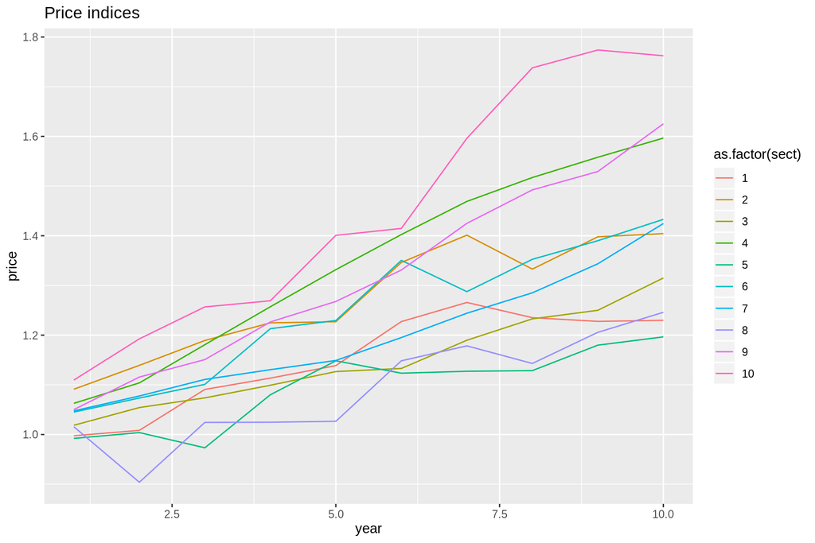

```r
sPriceM[, sectName := NULL]

ggplot(sPriceM, aes(x=year, y=price, group=sect, color=as.factor(sect))) + geom_line() +
    ggtitle("Price indices")
```

```r
setkey(sPriceM, sect, year)
setkey(fdata, sect, year)
fdataM <- fdata[sPriceM]
head(fdataM)
```

```
##    id year sect       re       lk       ll       lm       lA       lq
## 1:  1    1    1 1.549448 3.862172 3.774901 3.839995 3.880978 9.582840
## 2:  2    1    1 1.549448 3.911743 3.884606 3.802311 3.913071 9.352522
## 3:  3    1    1 1.549448 3.905252 3.934949 3.917053 3.931591 9.486415
## 4:  4    1    1 1.549448 3.987684 3.848051 3.882126 3.944045 9.446215
## 5:  5    1    1 1.549448 3.805230 3.862148 3.877565 3.899033 9.631169
## 6:  6    1    1 1.549448 3.886235 3.901880 3.880069 3.889287 9.484189
##           Q large large2 extralarge        K        L        M    price
## 1: 14513.58     0  FALSE      FALSE 47.56854 43.59320 46.52526 0.997581
## 2: 11527.86     0  FALSE      FALSE 49.98602 48.64775 44.80460 0.997581
## 3: 13179.46     0  FALSE      FALSE 49.66261 51.15955 50.25213 0.997581
## 4: 12660.16     0  FALSE      FALSE 53.92985 46.90155 48.52730 0.997581
## 5: 15232.24     0  FALSE      FALSE 44.93560 47.56742 48.30644 0.997581
## 6: 13150.16     0  FALSE      FALSE 48.72709 49.49542 48.42757 0.997581
```

## Merging datasets

- Create sector level variables

```r
sdata <- fdata[, list(sQ = sum(Q, na.rm=T), sL = sum(L, na.rm=T), sM = sum(M, na.rm=T)),
    by = list(sect, year)]
summary(sdata)
```

```
##       sect           year             sQ                sL
##  Min.   : 1.0   Min.   : 1.00   Min.   :1382622   Min.   : 4942
##  1st Qu.: 3.0   1st Qu.: 5.75   1st Qu.:1933496   1st Qu.: 6055
##  Median : 5.5   Median :10.50   Median :2709047   Median : 7468
##  Mean   : 5.5   Mean   :10.50   Mean   :2957696   Mean   : 7695
##  3rd Qu.: 8.0   3rd Qu.:15.25   3rd Qu.:3873070   3rd Qu.: 9239
##  Max.   :10.0   Max.   :20.00   Max.   :5424697   Max.   :11435
##        sM
##  Min.   :4858
##  1st Qu.:5439
##  Median :6181
##  Mean   :6227
##  3rd Qu.:6948
##  Max.   :8107
```

```r
dim(sdata)
```

```
## [1] 200   5
```

```r
# Set keys for datasets
setkey(fdata, sect, year)
setkey(sdata, sect, year)

# Merge it with the firm level data
hdata <- fdata[sdata]

# That's all...
dim(hdata)
```

```
## [1] 20000    19
```

```r
dim(fdata)
```

```
## [1] 20000    16
```

```r
identical(hdata$ll, fdata$ll)
```

```
## [1] TRUE
```

```r
# Shorter way
fdata[, c("sQ", "sL", "sM") := list(sum(Q, na.rm=T), sum(L, na.rm=T), sum(M, na.rm=T)),
    by = list(sect, year)]
identical(hdata, fdata)
```

```
## [1] FALSE
```

```r
# Find deviations from sectoral geometric averages
fdata[, lqdev := lq - mean(lq, na.rm=T), by = sect]
fdata[, lkdev := lk - mean(lk, na.rm=T), by = sect]
fdata[, lldev := ll - mean(ll, na.rm=T), by = sect]
fdata[, lmdev := lm - mean(lm, na.rm=T), by = sect]

# Find the growth rate of output
setkey(fdata, id, year)
fdata[, grq := lq - shift(lq, 1), by = id]
names(fdata)
```

```
##  [1] "id"         "year"       "sect"       "re"         "lk"
##  [6] "ll"         "lm"         "lA"         "lq"         "Q"
## [11] "large"      "large2"     "extralarge" "K"          "L"
## [16] "M"          "sQ"         "sL"         "sM"         "lqdev"
## [21] "lkdev"      "lldev"      "lmdev"      "grq"
```

```r
fdata[, mean(grq, na.rm = TRUE)]
```

```
## [1] 0.06946501
```

## Merging datasets

```r
DT <- data.table(x=rep(c("b","a","c"),each=3), y=c(1,3,6), v=1:9)
X <- data.table(x=c("c","b"), v=8:7, foo=c(4,2))

DT[X, on="x"]                               # right join
```

```
##    x y v i.v foo
## 1: c 1 7   8   4
## 2: c 3 8   8   4
## 3: c 6 9   8   4
## 4: b 1 1   7   2
## 5: b 3 2   7   2
## 6: b 6 3   7   2
```

```r
X[DT, on="x"]                               # left join
```

```
##    x  v foo y i.v
## 1: b  7   2 1   1
## 2: b  7   2 3   2
## 3: b  7   2 6   3
## 4: a NA  NA 1   4
## 5: a NA  NA 3   5
## 6: a NA  NA 6   6
## 7: c  8   4 1   7
## 8: c  8   4 3   8
## 9: c  8   4 6   9
```

```r
DT[X, on="x", nomatch=0]                    # inner join
```

```
##    x y v i.v foo
## 1: c 1 7   8   4
## 2: c 3 8   8   4
## 3: c 6 9   8   4
## 4: b 1 1   7   2
## 5: b 3 2   7   2
## 6: b 6 3   7   2
```

```r
DT[!X, on="x"]                              # not join
```

```
##    x y v
## 1: a 1 4
## 2: a 3 5
## 3: a 6 6
```

```r
DT[X, on=c(y="v")]                          # join DT$y to X$v
```

```
##       x y  v i.x foo
## 1: <NA> 8 NA   c   4
## 2: <NA> 7 NA   b   2
```

```r
DT[X, on="y==v"]                            # same
```

```
##       x y  v i.x foo
## 1: <NA> 8 NA   c   4
## 2: <NA> 7 NA   b   2
```

```r
DT[X, on=.(y<=foo)]                         # non-equi join
```

```
##    x y v i.x i.v
## 1: b 4 1   c   8
## 2: b 4 2   c   8
## 3: a 4 4   c   8
## 4: a 4 5   c   8
## 5: c 4 7   c   8
## 6: c 4 8   c   8
## 7: b 2 1   b   7
## 8: a 2 4   b   7
## 9: c 2 7   b   7
```

```r
DT[X, on="y<=foo"]                          # same
```

```
##    x y v i.x i.v
## 1: b 4 1   c   8
## 2: b 4 2   c   8
## 3: a 4 4   c   8
## 4: a 4 5   c   8
## 5: c 4 7   c   8
## 6: c 4 8   c   8
## 7: b 2 1   b   7
## 8: a 2 4   b   7
## 9: c 2 7   b   7
```

```r
DT[X, on=c("y<=foo")]                       # same
```

```
##    x y v i.x i.v
## 1: b 4 1   c   8
## 2: b 4 2   c   8
## 3: a 4 4   c   8
## 4: a 4 5   c   8
## 5: c 4 7   c   8
## 6: c 4 8   c   8
## 7: b 2 1   b   7
## 8: a 2 4   b   7
## 9: c 2 7   b   7
```

```r
DT[X, on=.(y>=foo)]                         # non-equi join
```

```
##    x y v i.x i.v
## 1: b 4 3   c   8
## 2: a 4 6   c   8
## 3: c 4 9   c   8
## 4: b 2 2   b   7
## 5: b 2 3   b   7
## 6: a 2 5   b   7
## 7: a 2 6   b   7
## 8: c 2 8   b   7
## 9: c 2 9   b   7
```

```r
DT[X, on=.(x, y<=foo)]                      # non-equi join
```

```
##    x y v i.v
## 1: c 4 7   8
## 2: c 4 8   8
## 3: b 2 1   7
```

```r
DT[X, .(x,y,x.y,v), on=.(x, y>=foo)]        # select x's join columns as well
```

```
##    x y x.y v
## 1: c 4   6 9
## 2: b 2   3 2
## 3: b 2   6 3
```

```r
DT[X, on="x", mult="first"]                 # first row of each group
```

```
##    x y v i.v foo
## 1: c 1 7   8   4
## 2: b 1 1   7   2
```

```r
DT[X, on="x", mult="last"]                  # last row of each group
```

```
##    x y v i.v foo
## 1: c 6 9   8   4
## 2: b 6 3   7   2
```

## Exercises

- Get the Penn World Table 9 dataset
  - Find the url of the data base
  - Use the **haven** library, and **read.stata** function
- Make it data table
- Check the structure of the dataset
- Calculate GDP per capita for all countries
  - Use the **rgdpo** and **pop** variables
- Check the structure of the dataset
- Drop Bermuda (BMU) from the sample
  - The **countrycode** variable keeps country codes
- Find the average GDP per capita for small and large countries for 2010
  - Small means population less than 1 million
- Find the average GDP per capita for poor and rich countries for all years after 2010
  - Poor means GDP per capita less than 10,000 USD
- Create a GDP per capita data set for Turkey, US, Korea and China
- Find GDP per capita relative to the US level for Turkey, Korea and China
- Plot relative GDP per capita for these countries

## Exercises

```r
# Load libraries
library(haven)
library(data.table)
library(ggplot2)

# Get the data
pwt <- read_stata("http://www.rug.nl/ggdc/docs/pwt90.dta")
pwt <- data.table(pwt)

# Structure
# str(pwt)

# GDP per capita
pwt[, gdpc := rgdpo / pop]
str(pwt)
```

```
## Classes 'data.table' and 'data.frame':   11830 obs. of  48 variables:
##  $ countrycode  : chr  "ABW" "ABW" "ABW" "ABW" ...
##   ..- attr(*, "label")= chr "3-letter ISO country code"
##   ..- attr(*, "format.stata")= chr "%9s"
##  $ country      : chr  "Aruba" "Aruba" "Aruba" "Aruba" ...
##   ..- attr(*, "label")= chr "Country name"
##   ..- attr(*, "format.stata")= chr "%34s"
##  $ currency_unit: chr  "Aruban Guilder" "Aruban Guilder" "Aruban Guilder" "Aruban Guilder" ...
##   ..- attr(*, "label")= chr "Currency unit"
##   ..- attr(*, "format.stata")= chr "%29s"
##  $ year         : num  1950 1951 1952 1953 1954 ...
##   ..- attr(*, "label")= chr "Year"
##   ..- attr(*, "format.stata")= chr "%9.0g"
##  $ rgdpe        : num  NA NA NA NA NA NA NA NA NA NA ...
##   ..- attr(*, "label")= chr "Expenditure-side real GDP at chained PPPs (in mil. 2011US$)"
##   ..- attr(*, "format.stata")= chr "%14.3g"
##  $ rgdpo        : num  NA NA NA NA NA NA NA NA NA NA ...
##   ..- attr(*, "label")= chr "Output-side real GDP at chained PPPs (in mil. 2011US$)"
##   ..- attr(*, "format.stata")= chr "%14.3g"
##  $ pop          : num  NA NA NA NA NA NA NA NA NA NA ...
##   ..- attr(*, "label")= chr "Population (in millions)"
##   ..- attr(*, "format.stata")= chr "%10.0g"
##  $ emp          : num  NA NA NA NA NA NA NA NA NA NA ...
##   ..- attr(*, "label")= chr "Number of persons engaged (in millions)"
##   ..- attr(*, "format.stata")= chr "%9.0g"
##  $ avh          : num  NA NA NA NA NA NA NA NA NA NA ...
##   ..- attr(*, "label")= chr "Average annual hours worked by persons engaged (source: The Conference Board)"
##   ..- attr(*, "format.stata")= chr "%10.0gc"
##  $ hc           : num  NA NA NA NA NA NA NA NA NA NA ...
##   ..- attr(*, "label")= chr "Human capital index, see note hc"
##   ..- attr(*, "format.stata")= chr "%9.0g"
##  $ ccon         : num  NA NA NA NA NA NA NA NA NA NA ...
##   ..- attr(*, "label")= chr "Real consumption of households and government, at current PPPs (in mil. 2011US$)"
##   ..- attr(*, "format.stata")= chr "%14.3g"
##  $ cda          : num  NA NA NA NA NA NA NA NA NA NA ...
##   ..- attr(*, "label")= chr "Real domestic absorption, see note cda"
##   ..- attr(*, "format.stata")= chr "%14.3g"
##  $ cgdpe        : num  NA NA NA NA NA NA NA NA NA NA ...
##   ..- attr(*, "label")= chr "Expenditure-side real GDP at current PPPs (in mil. 2011US$)"
##   ..- attr(*, "format.stata")= chr "%14.3g"
```

[output cut: 99 more lines]

```
##   ..- attr(*, "label")= chr "Price level of government consumption, price level of USA GDPo in 2011=1"
##   ..- attr(*, "format.stata")= chr "%10.0g"
##  $ pl_x         : num  NA NA NA NA NA NA NA NA NA NA ...
##   ..- attr(*, "label")= chr "Price level of exports, price level of USA GDPo in 2011=1"
##   ..- attr(*, "format.stata")= chr "%9.0g"
##  $ pl_m         : num  NA NA NA NA NA NA NA NA NA NA ...
##   ..- attr(*, "label")= chr "Price level of imports, price level of USA GDPo in 2011=1"
##   ..- attr(*, "format.stata")= chr "%9.0g"
##  $ pl_k         : num  NA NA NA NA NA NA NA NA NA NA ...
##   ..- attr(*, "label")= chr "Price level of the capital stock, price level of USA 2011=1"
##   ..- attr(*, "format.stata")= chr "%9.0g"
##  $ gdpc         : num  NA NA NA NA NA NA NA NA NA NA ...
##   ..- attr(*, "label")= chr "Output-side real GDP at chained PPPs (in mil. 2011US$)"
##   ..- attr(*, "format.stata")= chr "%14.3g"
##  - attr(*, ".internal.selfref")=<externalptr>
```

```r
# Drop Bermuda
pwt <- pwt[countrycode != "BMU"]
str(pwt)
```

```
## Classes 'data.table' and 'data.frame':   11765 obs. of  48 variables:
##  $ countrycode  : chr  "ABW" "ABW" "ABW" "ABW" ...
##   ..- attr(*, "label")= chr "3-letter ISO country code"
##   ..- attr(*, "format.stata")= chr "%9s"
##  $ country      : chr  "Aruba" "Aruba" "Aruba" "Aruba" ...
##   ..- attr(*, "label")= chr "Country name"
##   ..- attr(*, "format.stata")= chr "%34s"
##  $ currency_unit: chr  "Aruban Guilder" "Aruban Guilder" "Aruban Guilder" "Aruban Guilder" ...
##   ..- attr(*, "label")= chr "Currency unit"
##   ..- attr(*, "format.stata")= chr "%29s"
##  $ year         : num  1950 1951 1952 1953 1954 ...
##   ..- attr(*, "label")= chr "Year"
##   ..- attr(*, "format.stata")= chr "%9.0g"
##  $ rgdpe        : num  NA NA NA NA NA NA NA NA NA NA ...
##   ..- attr(*, "label")= chr "Expenditure-side real GDP at chained PPPs (in mil. 2011US$)"
##   ..- attr(*, "format.stata")= chr "%14.3g"
##  $ rgdpo        : num  NA NA NA NA NA NA NA NA NA NA ...
##   ..- attr(*, "label")= chr "Output-side real GDP at chained PPPs (in mil. 2011US$)"
##   ..- attr(*, "format.stata")= chr "%14.3g"
##  $ pop          : num  NA NA NA NA NA NA NA NA NA NA ...
##   ..- attr(*, "label")= chr "Population (in millions)"
##   ..- attr(*, "format.stata")= chr "%10.0g"
##  $ emp          : num  NA NA NA NA NA NA NA NA NA NA ...
##   ..- attr(*, "label")= chr "Number of persons engaged (in millions)"
##   ..- attr(*, "format.stata")= chr "%9.0g"
##  $ avh          : num  NA NA NA NA NA NA NA NA NA NA ...
##   ..- attr(*, "label")= chr "Average annual hours worked by persons engaged (source: The Conference Board)"
##   ..- attr(*, "format.stata")= chr "%10.0gc"
##  $ hc           : num  NA NA NA NA NA NA NA NA NA NA ...
##   ..- attr(*, "label")= chr "Human capital index, see note hc"
##   ..- attr(*, "format.stata")= chr "%9.0g"
##  $ ccon         : num  NA NA NA NA NA NA NA NA NA NA ...
##   ..- attr(*, "label")= chr "Real consumption of households and government, at current PPPs (in mil. 2011US$)"
##   ..- attr(*, "format.stata")= chr "%14.3g"
##  $ cda          : num  NA NA NA NA NA NA NA NA NA NA ...
##   ..- attr(*, "label")= chr "Real domestic absorption, see note cda"
##   ..- attr(*, "format.stata")= chr "%14.3g"
##  $ cgdpe        : num  NA NA NA NA NA NA NA NA NA NA ...
##   ..- attr(*, "label")= chr "Expenditure-side real GDP at current PPPs (in mil. 2011US$)"
##   ..- attr(*, "format.stata")= chr "%14.3g"
```

[output cut: 99 more lines]

```
##   ..- attr(*, "label")= chr "Price level of government consumption, price level of USA GDPo in 2011=1"
##   ..- attr(*, "format.stata")= chr "%10.0g"
##  $ pl_x         : num  NA NA NA NA NA NA NA NA NA NA ...
##   ..- attr(*, "label")= chr "Price level of exports, price level of USA GDPo in 2011=1"
##   ..- attr(*, "format.stata")= chr "%9.0g"
##  $ pl_m         : num  NA NA NA NA NA NA NA NA NA NA ...
##   ..- attr(*, "label")= chr "Price level of imports, price level of USA GDPo in 2011=1"
##   ..- attr(*, "format.stata")= chr "%9.0g"
##  $ pl_k         : num  NA NA NA NA NA NA NA NA NA NA ...
##   ..- attr(*, "label")= chr "Price level of the capital stock, price level of USA 2011=1"
##   ..- attr(*, "format.stata")= chr "%9.0g"
##  $ gdpc         : num  NA NA NA NA NA NA NA NA NA NA ...
##   ..- attr(*, "label")= chr "Output-side real GDP at chained PPPs (in mil. 2011US$)"
##   ..- attr(*, "format.stata")= chr "%14.3g"
##  - attr(*, ".internal.selfref")=<externalptr>
```

```r
# GDP per capita
pwt[year == 2010, mean(gdpc, na.rm = TRUE), by = list(year, pop > 1)]
```

```
##    year   pop       V1
## 1: 2010 FALSE 21780.64
## 2: 2010  TRUE 16232.58
```

```r
# GDP per capita
pwt[year > 2010, mean(gdpc, na.rm = TRUE), by = list(year, gdpc > 10000)]
```

```
##    year gdpc > 10000        V1
## 1: 2011         TRUE 29432.780
## 2: 2012         TRUE 29638.135
## 3: 2013         TRUE 30292.655
## 4: 2014         TRUE 29189.817
## 5: 2011        FALSE  4367.621
## 6: 2012        FALSE  4413.643
## 7: 2013        FALSE  4377.382
## 8: 2014        FALSE  4096.922
```

```r
# GDP per capita for selected countries
pwt4 <- pwt[countrycode %in% c("TUR", "USA", "CHN", "KOR"),
        list(countrycode, gdpc, year)]

table(pwt4$countrycode)
```

```
##
## CHN KOR TUR USA
##  65  65  65  65
```

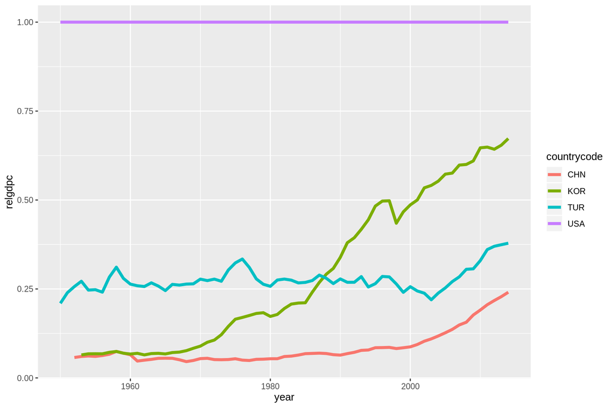

```r
# Relative GDP per capita
pwt4[countrycode == "USA", usgdpc := gdpc]
pwt4[, relgdpc := gdpc / sum(usgdpc, na.rm = T), by = year]

ggplot(pwt4, aes(x = year, y = relgdpc, color = countrycode)) + geom_line(size = 1.5)
```